# LearningSpoonsR_lifeCountry

Geon Seung Lee

2019-01-16

## **각 대륙별 GDP 및 기대수명에 대한 박스플롯을 만들어보세요.**

```r
library(dplyr)
library(ggplot2)
dataset <- read.csv("lifeCountry.csv", stringsAsFactors = FALSE)
```

**박스플롯에서 아웃라이러를 제외한 최대/상위25/중간값/하위25/최소 데이터값만 표기하고 싶습니다.**

### Step 1. 기본 박스 플랏 그리기

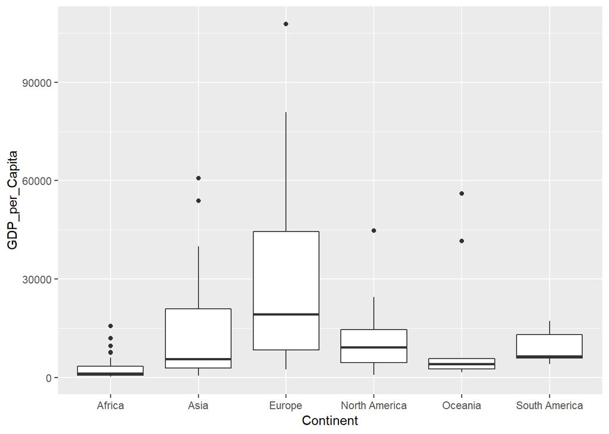

```r
a <- ggplot(dataset, aes(x=Continent, y=GDP_per_Capita)) + geom_boxplot()
a
```

### Step 2. `geom_text`로 통계량 추가하기

##### Step 2-1. 먼저 통계량을 모아놓은 `GDP_stats`라는 데이터 프레임을 만듭니다.

```r
summary(dataset$GDP_per_Capita)
```

```
##    Min. 1st Qu.  Median    Mean 3rd Qu.    Max.
##     221    2039    5599   13541   16443  107708
```

```r
GDP_stats <- dataset %>%
  group_by(Continent) %>%
  summarise(Min = summary(GDP_per_Capita)[1],
            Q1 = summary(GDP_per_Capita)[2],
            Median = summary(GDP_per_Capita)[3],
            Q3 = summary(GDP_per_Capita)[5],
            Max = summary(GDP_per_Capita)[6])
GDP_stats[,-1] <- round(GDP_stats[,-1])
GDP_stats
```

```
## # A tibble: 6 x 6
##   Continent     Min         Q1          Median      Q3          Max
##   <chr>         <S3: table> <S3: table> <S3: table> <S3: table> <S3: table>
## 1 Africa         221         702         1206        3429        15658
## 2 Asia           572        2886         5677       20957        60811
## 3 Europe        2458        8420        19282       44561       107708
## 4 North America  761        4500         9249       14596        44773
## 5 Oceania       1625        2689         4176        5761        56135
## 6 South America 4138        5966         6506       13050        17252
```

##### Step 2-2. `geom_text`를 이용해서 label을 추가합니다.

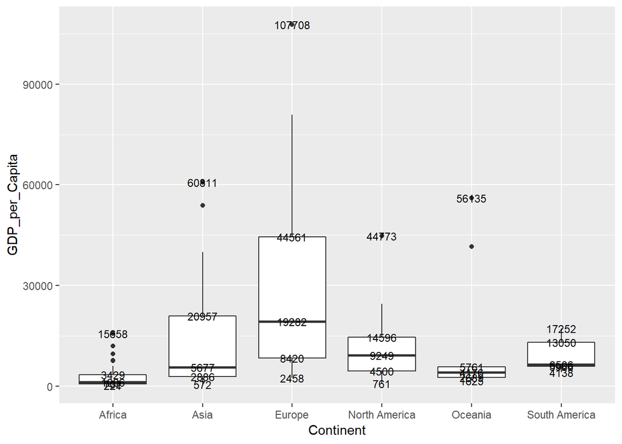

```r
a +
  geom_text(data = GDP_stats, aes(x=Continent, y=Min, label=Min), size = 3) +
  geom_text(data = GDP_stats, aes(x=Continent, y=Q1, label=Q1), size = 3) +
  geom_text(data = GDP_stats, aes(x=Continent, y=Median, label=Median), size = 3) +
  geom_text(data = GDP_stats, aes(x=Continent, y=Q3, label=Q3), size = 3) +
  geom_text(data = GDP_stats, aes(x=Continent, y=Max, label=Max), size = 3)
```

##### Step 2-3. 텍스트가 선이랑 겹쳐서 잘 보이지 않네요?

- 박스플랏의 크기가 촘촘하여 텍스트를 넣을 자리가 별로 없습니다. 이런 경우에는 박스 플랏을 더 크게 만드는 것이 좋아보입니다.
- Chunk control 부분에 `{r, fig.height = 10}`를 추가하였습니다. (코드 확인해주세요)
- Rstudio내에서 보면 사이즈가 그대로입니다. 하지만 rendering된 html에는 크기가 커진 것을 확인할 있습니다.

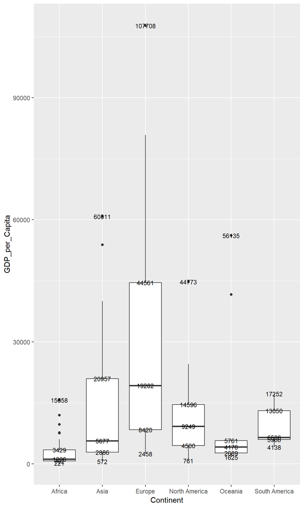

```r
a <- ggplot(dataset, aes(x=Continent, y=GDP_per_Capita)) + geom_boxplot()
a +
  geom_text(data = GDP_stats, aes(x=Continent, y=Min, label=Min), size = 3) +
  geom_text(data = GDP_stats, aes(x=Continent, y=Q1, label=Q1), size = 3) +
  geom_text(data = GDP_stats, aes(x=Continent, y=Median, label=Median), size = 3) +
  geom_text(data = GDP_stats, aes(x=Continent, y=Q3, label=Q3), size = 3) +
  geom_text(data = GDP_stats, aes(x=Continent, y=Max, label=Max), size = 3)
```

##### Step 2-4. 조금 나아지긴 했지만 여전히 겹쳐네요. 텍스트 위치를 조금 옮겨 보겠습니다.

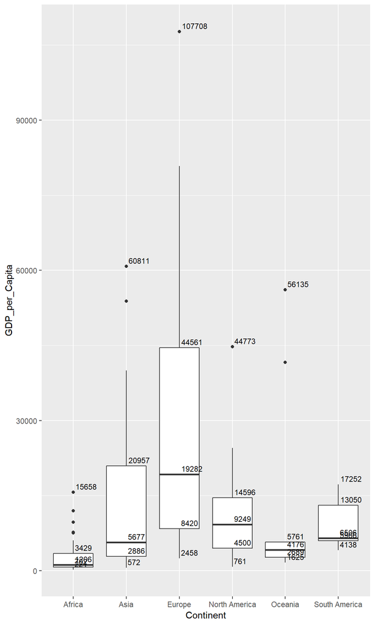

```r
h_shift = -0.1 # horizontal shift
v_shift = -0.5 # vertical shift
a +
  geom_text(data = GDP_stats,
            aes(x=Continent, y=Min, label=Min, hjust=h_shift, vjust=v_shift),
            size = 3) +
  geom_text(data = GDP_stats,
            aes(x=Continent, y=Q1, label=Q1, hjust=h_shift, vjust=v_shift),
            size = 3) +
  geom_text(data = GDP_stats,
            aes(x=Continent, y=Median, label=Median, hjust=h_shift, vjust=v_shift),
            size = 3) +
  geom_text(data = GDP_stats,
            aes(x=Continent, y=Q3, label=Q3, hjust=h_shift, vjust=v_shift),
            size = 3) +
  geom_text(data = GDP_stats,
            aes(x=Continent, y=Max, label=Max, hjust=h_shift, vjust=v_shift),
            size = 3)
```

- Africa 같은 대륙은 Q1, Median, Q3가 촘촘하여 text를 넣을 공간이 없습니다.
- 위의 코드에서 Q1과 Q3에는 `hjust`값을 양수로 넣어준다면 Q1과 Q3는 왼쪽으로 배열할 수 있습니다.

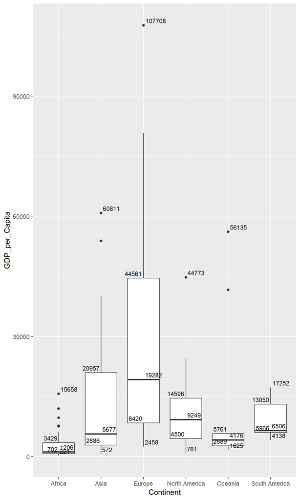

```r
h_shift = -0.1
h_shift2 = 1.1
v_shift = -0.5
a +
  geom_text(data = GDP_stats,
            aes(x=Continent, y=Min, label=Min, hjust=h_shift, vjust=v_shift),
            size = 3) +
  geom_text(data = GDP_stats,
            aes(x=Continent, y=Q1, label=Q1, hjust=h_shift2, vjust=v_shift),
            size = 3) +
  geom_text(data = GDP_stats,
            aes(x=Continent, y=Median, label=Median, hjust=h_shift, vjust=v_shift),
            size = 3) +
  geom_text(data = GDP_stats,
            aes(x=Continent, y=Q3, label=Q3, hjust=h_shift2, vjust=v_shift),
            size = 3) +
  geom_text(data = GDP_stats,
            aes(x=Continent, y=Max, label=Max, hjust=h_shift, vjust=v_shift),
            size = 3)
```

이런 식으로 text의 위치를 조금씩 조정한다면 원하는 모양에 가까워 질 것 같습니다.